# 03_analysis

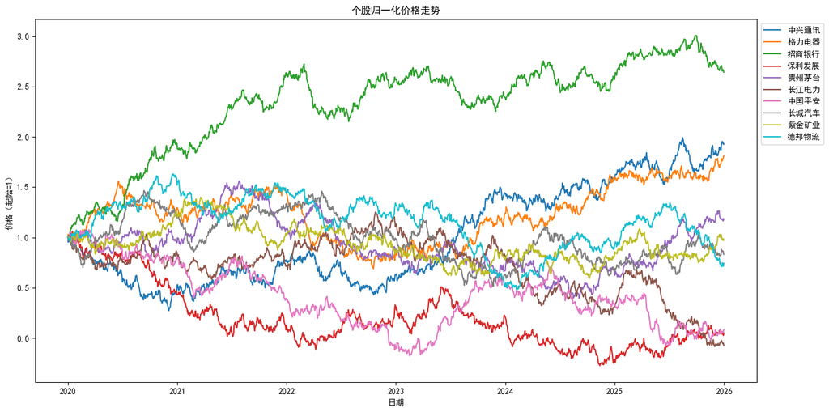

```python
import os
import pandas as pd
import numpy as np
import matplotlib.pyplot as plt
import seaborn as sns
import statsmodels.api as sm
from scipy import stats

plt.rcParams['font.sans-serif'] = ['SimHei']
plt.rcParams['axes.unicode_minus'] = False

# ======================
# 读取数据
# ======================
df_all = pd.read_csv('data/clean/stock_clean.csv', parse_dates=['date'])
df_all['code'] = df_all['code'].astype(str).str.zfill(6)
exist_codes = sorted(df_all['code'].unique())

stock_name = {
    '601318': '中国平安',
    '600036': '招商银行',
    '601633': '长城汽车',
    '000651': '格力电器',
    '600048': '保利发展',
    '600519': '贵州茅台',
    '601899': '紫金矿业',
    '600900': '长江电力',
    '000063': '中兴通讯',
    '603056': '德邦物流'
}

# ======================
# 图1：归一化走势
# ======================
df_pivot = df_all.pivot_table(index='date', columns='code', values='收盘')
df_norm = df_pivot / df_pivot.iloc[0]

plt.figure(figsize=(14, 7))
for code in exist_codes:
    plt.plot(df_norm.index, df_norm[code], label=stock_name[code])
plt.title('个股归一化价格走势')
plt.xlabel('日期')
plt.ylabel('价格（起始=1）')
plt.legend(bbox_to_anchor=(1, 1))
plt.tight_layout()
plt.savefig('output/走势对比图.png', dpi=150, bbox_inches='tight')
plt.show()

# ======================
```

### 图1：个股归一化价格走势分析

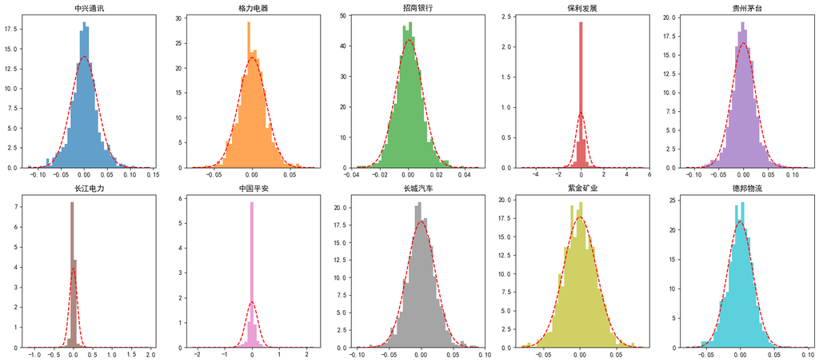

```python
# 图2：收益率分布（彩色好看版）
# ======================
ret_df = df_all.pivot_table(index='date', columns='code', values='log_return')
fig, axes = plt.subplots(2, 5, figsize=(18, 8))
axes = axes.flatten()
colors = plt.cm.tab10.colors

for idx, code in enumerate(exist_codes):
    ret = ret_df[code].dropna()
    axes[idx].hist(ret, bins=40, alpha=0.7, density=True, color=colors[idx])
    mu, sigma = ret.mean(), ret.std()
    x = np.linspace(ret.min(), ret.max(), 100)
    y = stats.norm.pdf(x, mu, sigma)
    axes[idx].plot(x, y, 'r--', linewidth=1.5)
    axes[idx].set_title(f"{stock_name[code]}")
plt.tight_layout()
plt.savefig('output/收益率分布.png', dpi=150)
plt.show()

# ======================
```

### 图2：个股日收益率分布分析

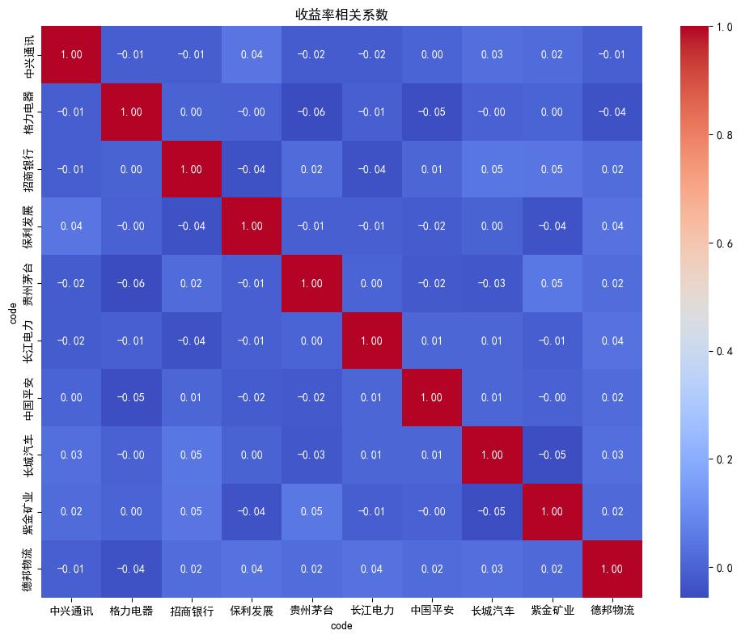

```python
# 图3：相关系数热力图
# ======================
corr = ret_df.corr()
plt.figure(figsize=(10, 8))
sns.heatmap(corr, annot=True, fmt='.2f', cmap='coolwarm',
            xticklabels=[stock_name[c] for c in exist_codes],
            yticklabels=[stock_name[c] for c in exist_codes])
plt.title('收益率相关系数')
plt.tight_layout()
plt.savefig('output/相关系数热力图.png', dpi=150)
plt.show()

# ======================
```

### 图3：个股收益率相关系数分析

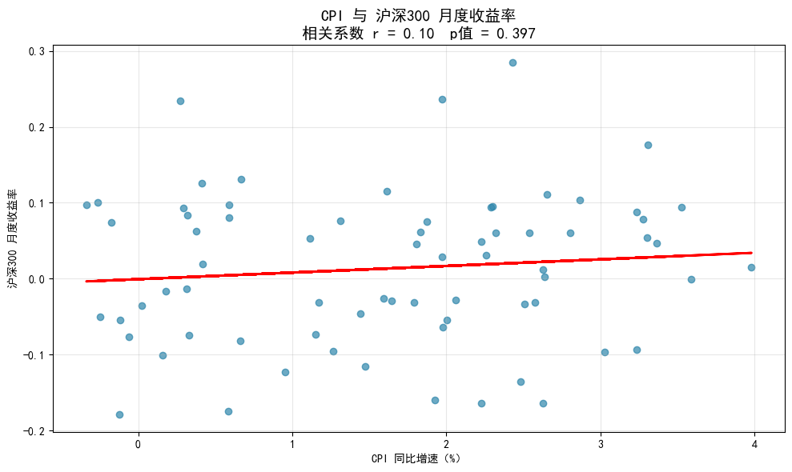

```python
# ======================
# 图4：宏观指标(CPI) vs 沪深300 月度收益率（作业要求！）
# ======================
import pandas as pd
import numpy as np
import matplotlib.pyplot as plt
from scipy.stats import pearsonr

# 1. 读取数据
df_stock = pd.read_csv('data/clean/stock_clean.csv', parse_dates=['date'])
df_hs300 = pd.read_csv('data/index/index_hs300.csv', parse_dates=['日期'])
df_cpi = pd.read_csv('data/macro/macro_cpi.csv', parse_dates=['月份'])

# 2. 计算沪深300月度收益率
df_hs300['month'] = df_hs300['日期'].dt.to_period('M')
df_hs300['月度收益'] = np.log(df_hs300.groupby('month')['收盘'].transform('last') /
                             df_hs300.groupby('month')['收盘'].transform('first'))
df_hs300_month = df_hs300[['month', '月度收益']].drop_duplicates()

# 3. CPI 月度数据
df_cpi['month'] = df_cpi['月份'].dt.to_period('M')
df_cpi = df_cpi.rename(columns={'同比增长': 'cpi'})

# 4. 合并
df_merge = pd.merge(df_hs300_month, df_cpi[['month', 'cpi']], on='month', how='inner').dropna()

# 5. 计算相关系数
x = df_merge['cpi']
y = df_merge['月度收益']
r, p_val = pearsonr(x, y)

# 6. 画图
plt.figure(figsize=(10, 6))
plt.scatter(x, y, alpha=0.7, color='#2E86AB')

# 拟合线
z = np.polyfit(x, y, 1)
p = np.poly1d(z)
plt.plot(x, p(x), "r-", linewidth=2)

# 标注相关系数
plt.title(f'CPI 与 沪深300 月度收益率\n相关系数 r = {r:.2f}  p值 = {p_val:.3f}', fontsize=14)
plt.xlabel('CPI 同比增速（%）')
plt.ylabel('沪深300 月度收益率')
plt.grid(alpha=0.3)
plt.tight_layout()
plt.savefig('output/宏观_股市关系.png', dpi=150)
plt.show()
```

### 图4：宏观指标（CPI）与沪深300收益率关系分析

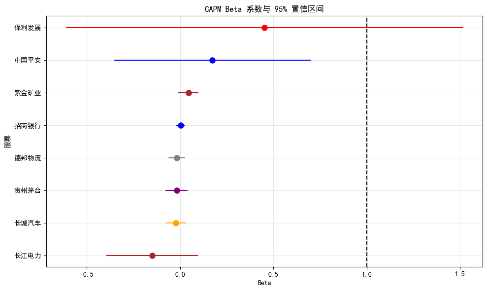

```python
# ======================
# 5.1 CAPM
# ======================
import pandas as pd
import numpy as np
import matplotlib.pyplot as plt
import statsmodels.api as sm

# 正确股票映射
valid_codes = [
    '601318','600036','601633','000651','600048',
    '600519','601899','600900','000063','603056'
]

stock_name = {
    '601318': '中国平安','600036': '招商银行','601633': '长城汽车',
    '000651': '格力电器','600048': '保利发展','600519': '贵州茅台',
    '601899': '紫金矿业','600900': '长江电力','000063': '中兴通讯','603056': '德邦物流'
}
industry_map = {
    '601318': '银行','600036': '银行','601633': '汽车','000651': '家电',
    '600048': '地产','600519': '白酒','601899': '能源','600900': '能源',
    '000063': '通信','603056': '物流'
}

# 读取数据
df = pd.read_csv('data/clean/stock_clean.csv', parse_dates=['date'])
df_hs = pd.read_csv('data/index/index_hs300.csv', parse_dates=['日期'])
df_hs['mkt_return'] = np.log(df_hs['收盘'] / df_hs['收盘'].shift(1))
df = df.merge(df_hs[['日期', 'mkt_return']], left_on='date', right_on='日期').dropna()

df = df[df['code'].astype(str).isin(valid_codes)]
df['code'] = df['code'].astype(str)

rf = 0.02 / 252
capm_results = []

for code in df['code'].unique():
    d = df[df['code'] == code].copy()
    ri = d['log_return']
    rm = d['mkt_return']
    y = ri - rf
    x = rm - rf
    X = sm.add_constant(x)
    model = sm.OLS(y, X).fit()

    alpha = model.params.iloc[0]
    beta = model.params.iloc[1]
    p_alpha = model.pvalues.iloc[0]
    ci = model.conf_int()
    ci_lower = ci.iloc[1, 0]
    ci_upper = ci.iloc[1, 1]
    r2 = model.rsquared

    capm_results.append({
        'code': code,
        'name': stock_name[code],
        'industry': industry_map[code],
        'alpha': alpha,
        'p_alpha': p_alpha,
        'beta': beta,
        'ci_low': ci_lower,
        'ci_up': ci_upper,
        'R2': r2
    })

capm_df = pd.DataFrame(capm_results)
capm_df.to_csv('output/CAPM回归结果.csv', index=False, encoding='utf-8-sig')

# ======================
# 画图：Beta 系数图
# ======================
colors = {
    '银行':'blue','汽车':'orange','家电':'green','地产':'red',
    '白酒':'purple','能源':'brown','通信':'pink','物流':'gray'
}
capm_df = capm_df.sort_values('beta')

plt.figure(figsize=(10,6))
for _, row in capm_df.iterrows():
    plt.errorbar(
        row['beta'], row['name'],
        xerr=[[ row['beta']-row['ci_low']], [row['ci_up']-row['beta']]],
        fmt='o', color=colors[row['industry']], markersize=8
    )
plt.axvline(1, color='black', linestyle='--')
plt.title('CAPM Beta 系数与 95% 置信区间')
plt.xlabel('Beta')
plt.ylabel('股票')
plt.grid(alpha=0.3)
plt.tight_layout()
plt.savefig('output/CAPM_Beta图.png', dpi=150)
plt.show()
```

## 5.1 CAPM 模型估计与分析

### 3. R² 差异解释

```python
import os
os.system("jupyter nbconvert --to html 03_analysis.ipynb --output report.html")
print("✅ 报告已生成")
```

```
✅ 报告已生成
```